# An implementation of the STAMP protocol.

atb abelew@gmail.com

2022-02-07

# 1 Fun with STAMP

This document is intended to step through the STAMP protocol as described in:

1. “Sequence tag–based analysis of microbial population dynamics”
2. “Deciphering the landscape of host barriers to Listeria monocytogenes infection”
3. “Systemic infection facilitates transmission of Pseudomonas aeruginosa in mice”

And a couple of other papers which I do not have open right now. I am using a reference implementation kindly provided by Dr. Lee and Asan which came from one of the groups listed above, either they haven’t told me who or I forgot. Assuming I receive permission, I will include that implementation here.

# 2 Introduction

There are two broad strokes to the process:

1. Create a calibration curve showing the relationship between observed CFU and tags observed in calibration samples.
2. Introduce a known set of tags to experimental samples, allow them to propagate through the experimental organism, collect DNA samples, quantify tags observed at different times/locations, cross reference them against the calibration curve, and use that to estimate population bottlenecks during the infection process.

From the perspective of the experimental scientist (Dr. Lee and Asan), step 1 is relatively simple and step 2 is quite onerous. From the perspective of a computer nerd, these two vastly different steps are similar and most of the work occurs in step 1. This is nice because I have not yet received experimental results. This document will therefore describe the processing required to go from sequencer data to a functional calibration curve. Along the way, I will introduce some alternatives to the original protocol and provide some example ways to estimate bottlenecks given artificial experimental input.

With the above in mind, the tasks to process new samples are:

1. Create a sample sheet, defining the reference, calibration, and experimental samples. I included my copy with this package.
2. Trim the raw reads. I used cutadapt through my cyoa preprocessing tool and included one output script with this package. I will leave trimming multiple samples as an exercise to the reader.
3. Count the observed tags. The authors performed this with qiime. I will show how to do that along with a somewhat more parsimonious method.
4. Filter the tags and quantify the Nb values.
5. Create a calibration curve using the quantified tags.
6. Estimate experimental Nb/CFU using the calibration curve.
7. Make pretty pictures along the way.

# 3 Installation

The R package may be installed via:

```r
devtools::install_github("abelew/stampr")
```

# 4 Sample metadata

The sample sheet I created is an excel worksheet with one row for each sample. The most important columns are: “sampleid”, “replicate”, “type”, “CFU”, “index_table”, and “qiime_otus”. I think they are mostly self-explanatory, here are the relevant details:

1. ‘type’ should be either ‘calibration’, ‘reference’, or ‘experimental’.
2. ‘CFU’ should be filled in for the calibration and reference samples. It will be ignored and potentially overwritten for anything labeled ‘experimental’.
3. ‘index_table’ should include filenames for the outputs of my index counter script (included in this package) ‘count_idx.pl’.
4. ‘qiime_otus’ should include the filenames produced by qiime’s pick_otus.py script.

The following block shows the sample sheet from our data. It is worth noting that I cheated and used my hpgltools’ extract_metadata() function to read it, it removes any punctuation or shenanigans from the metadata sheet (in case someone with twitchy fingers added an extraneous space in a filename or something weird).

```r
basedir <- system.file("extdata", package = "stampr")
metadata_file <- file.path(basedir, "all_samples.xlsx")
meta <- hpgltools::extract_metadata(metadata_file)
```

```
## Did not find the condition column in the sample sheet.
```

```
## Filling it in as undefined.
```

```r
knitr::kable(meta)
```

|  | sampleid | replicate | batch | type | cfu | dilution | rawfastq | trimmedfastq | indextable | qiimeotus | condition |
| --- | --- | --- | --- | --- | --- | --- | --- | --- | --- | --- | --- |
| a1 | a1 | a | b202012 | calibration | 4 | 0e+00 | preprocessing/a1/r1.fastq.xz | preprocessing/a1/r1-trimmed_ca.fastq.xz | preprocessing/a1/idx_count.txt.xz | preprocessing/a1/a1_otus.txt.xz | undefined |
| a2 | a2 | a | b202012 | calibration | 37 | 0e+00 | preprocessing/a2/r1.fastq.xz | preprocessing/a2/r1-trimmed_ca.fastq.xz | preprocessing/a2/idx_count.txt.xz | preprocessing/a2/a2_otus.txt.xz | undefined |
| a3 | a3 | a | b202012 | calibration | 450 | 0e+00 | preprocessing/a3/r1.fastq.xz | preprocessing/a3/r1-trimmed_ca.fastq.xz | preprocessing/a3/idx_count.txt.xz | preprocessing/a3/a3_otus.txt.xz | undefined |
| a4 | a4 | a | b202012 | calibration | 3850 | 1e-04 | preprocessing/a4/r1.fastq.xz | preprocessing/a4/r1-trimmed_ca.fastq.xz | preprocessing/a4/idx_count.txt.xz | preprocessing/a4/a4_otus.txt.xz | undefined |
| a5 | a5 | a | b202012 | calibration | 30000 | 1e-03 | preprocessing/a5/r1.fastq.xz | preprocessing/a5/r1-trimmed_ca.fastq.xz | preprocessing/a5/idx_count.txt.xz | preprocessing/a5/a5_otus.txt.xz | undefined |
| a6 | a6 | a | b202012 | calibration | 345000 | 1e-02 | preprocessing/a6/r1.fastq.xz | preprocessing/a6/r1-trimmed_ca.fastq.xz | preprocessing/a6/idx_count.txt.xz | preprocessing/a6/a6_otus.txt.xz | undefined |
| a7 | a7 | a | b202012 | calibration | 4350000 | 1e-01 | preprocessing/a7/r1.fastq.xz | preprocessing/a7/r1-trimmed_ca.fastq.xz | preprocessing/a7/idx_count.txt.xz | preprocessing/a7/a7_otus.txt.xz | undefined |
| a8 | a8 | a | b202012 | reference | 30000000 | 1e+00 | preprocessing/a8/r1.fastq.xz | preprocessing/a8/r1-trimmed_ca.fastq.xz | preprocessing/a8/idx_count.txt.xz | preprocessing/a8/a8_otus.txt.xz | undefined |
| b2 | b2 | b | b202012 | calibration | 22 | 0e+00 | preprocessing/b2/r1.fastq.xz | preprocessing/b2/r1-trimmed_ca.fastq.xz | preprocessing/b2/idx_count.txt.xz | preprocessing/b2/b2_otus.txt.xz | undefined |
| b3 | b3 | b | b202012 | calibration | 200 | 0e+00 | preprocessing/b3/r1.fastq.xz | preprocessing/b3/r1-trimmed_ca.fastq.xz | preprocessing/b3/idx_count.txt.xz | preprocessing/b3/b3_otus.txt.xz | undefined |
| b4 | b4 | b | b202012 | calibration | 2900 | 1e-04 | preprocessing/b4/r1.fastq.xz | preprocessing/b4/r1-trimmed_ca.fastq.xz | preprocessing/b4/idx_count.txt.xz | preprocessing/b4/b4_otus.txt.xz | undefined |
| b5 | b5 | b | b202012 | calibration | 26500 | 1e-03 | preprocessing/b5/r1.fastq.xz | preprocessing/b5/r1-trimmed_ca.fastq.xz | preprocessing/b5/idx_count.txt.xz | preprocessing/b5/b5_otus.txt.xz | undefined |
| b6 | b6 | b | b202012 | calibration | 195000 | 1e-02 | preprocessing/b6/r1.fastq.xz | preprocessing/b6/r1-trimmed_ca.fastq.xz | preprocessing/b6/idx_count.txt.xz | preprocessing/b6/b6_otus.txt.xz | undefined |
| b7 | b7 | b | b202012 | calibration | 3650000 | 1e-01 | preprocessing/b7/r1.fastq.xz | preprocessing/b7/r1-trimmed_ca.fastq.xz | preprocessing/b7/idx_count.txt.xz | preprocessing/b7/b7_otus.txt.xz | undefined |
| b8 | b8 | b | b202012 | reference | 34000000 | 1e+00 | preprocessing/b8/r1.fastq.xz | preprocessing/b8/r1-trimmed_ca.fastq.xz | preprocessing/b8/idx_count.txt.xz | preprocessing/b8/b8_otus.txt.xz | undefined |
| c1 | c1 | c | b202012 | calibration | 8 | 0e+00 | preprocessing/c1/r1.fastq.xz | preprocessing/c1/r1-trimmed_ca.fastq.xz | preprocessing/c1/idx_count.txt.xz | preprocessing/c1/c1_otus.txt.xz | undefined |
| c2 | c2 | c | b202012 | calibration | 78 | 0e+00 | preprocessing/c2/r1.fastq.xz | preprocessing/c2/r1-trimmed_ca.fastq.xz | preprocessing/c2/idx_count.txt.xz | preprocessing/c2/c2_otus.txt.xz | undefined |
| c3 | c3 | c | b202012 | calibration | 800 | 0e+00 | preprocessing/c3/r1.fastq.xz | preprocessing/c3/r1-trimmed_ca.fastq.xz | preprocessing/c3/idx_count.txt.xz | preprocessing/c3/c3_otus.txt.xz | undefined |
| c4 | c4 | c | b202012 | calibration | 7950 | 1e-04 | preprocessing/c4/r1.fastq.xz | preprocessing/c4/r1-trimmed_ca.fastq.xz | preprocessing/c4/idx_count.txt.xz | preprocessing/c4/c4_otus.txt.xz | undefined |
| c5 | c5 | c | b202012 | calibration | 57500 | 1e-03 | preprocessing/c5/r1.fastq.xz | preprocessing/c5/r1-trimmed_ca.fastq.xz | preprocessing/c5/idx_count.txt.xz | preprocessing/c5/c5_otus.txt.xz | undefined |
| c6 | c6 | c | b202012 | calibration | 590000 | 1e-02 | preprocessing/c6/r1.fastq.xz | preprocessing/c6/r1-trimmed_ca.fastq.xz | preprocessing/c6/idx_count.txt.xz | preprocessing/c6/c6_otus.txt.xz | undefined |
| c7 | c7 | c | b202012 | calibration | 5900000 | 1e-01 | preprocessing/c7/r1.fastq.xz | preprocessing/c7/r1-trimmed_ca.fastq.xz | preprocessing/c7/idx_count.txt.xz | preprocessing/c7/c7_otus.txt.xz | undefined |
| c8 | c8 | c | b202012 | reference | 71000000 | 1e+00 | preprocessing/c8/r1.fastq.xz | preprocessing/c8/r1-trimmed_ca.fastq.xz | preprocessing/c8/idx_count.txt.xz | preprocessing/c8/c8_otus.txt.xz | undefined |

Note that I put all the raw reads in a series of directories in ‘preprocessing’. I also recompressed every sample and symbolicly linked them to ‘r1.fastq.xz’.

# 5 Trim the raw reads

I am not going to include the raw reads in this, but here is the relevant portion of the script produced by cyoa which performed the trimming for one sample. This was one invocation performed on our computing cluster, so I will remove all the cluster-specific stuff and focus on the important pieces. Also, if you look at the version of the script I included there are a few differences:

1. I shortened all these paths to relative.
2. My processor on the cluster by default trims some other adapters which I removed for clarity from this.
3. I added explicit xz invocations to this. On the cluster I have a series of cleanup jobs which do this on multiple nodes.
4. By default, the less(1) command will not work to read xz/gz/bz2 compressed files, and requires the user to first set the LESSOPEN variable, which I included at the top.

```bash
## This was taken from '07ca_r1.sh'
LESSOPEN=| /usr/bin/lesspipe %s
mkdir -p preprocessing/a1/outputs/cutadapt && \
 less r1.fastq.xz | cutadapt -  \
  -a GTCATAGCTGTTT \
  -e 0.1 -n 3 \
  -m 8 -M 42 \
  --too-short-output = preprocessing/a1/outputs/cutadapt/r1_tooshort.fastq \
  --too-long-output = preprocessing/a1/outputs/cutadapt/r1_toolong.fastq \
  --untrimmed-output = preprocessing/a1/outputs/cutadapt/r1_untrimmed.fastq \
  2>outputs/cutadapt.err 1>r1-trimmed_ca.fastq
xz -9e r1-trimmed_ca.fastq preprocessing/a1/outputs/cutadapt/r1_tooshort.fastq \
   preprocessing/a1/outputs/cutadapt/r1_toolong.fastq \
   preprocessing/a1/outputs/cutadapt/r1_untrimmed.fastq
```

# 6 Count observed tags

The original authors used qiime to do this. I wrote a simple perl script for it and included it in this package. The perl script has the small advantage of being documented and rather fast.

## 6.1 Qiime OTU quantification

This invocation is from my session on the computing cluster. Again, this is just one example. Also, I did not feel like using the qiime fastq to fasta converter, I am including it below. In addition, I found notes in the various supplemental materials for the previous papers which said that the authors used 99% and 90% identity for pick_otus. The invocation below uses 90%.

```bash
module add qiime
fq2fa () {
    paste - - - - < ${1} | cut -f 1,2 | sed 's/^@/>/' | tr "\t" "\n" > ${2}
}

cd preprocessing
start=$(pwd)
for sample in *; do
    cd ${sample}
    fq2fa $(less r1-trimmed_ca.fastq.xz) ${sample}.fasta
    pick_otus.py -i ${sample}.fasta -o $(pwd) -s 0.9
    rm ${sample}.fasta
    xz -9e ${sample}_otus.txt
    cd ${start}
done
```

## 6.2 Perl tag counting

In contrast, I wrote a short perl script which counts tags without using ucsearch/blast/etc from qiime. This has advantages of speed, simplicity, and it only counts identical tags as opposed to the potential mismatches allowed by the alignment tools. The output files are also much simpler 2 column tsv files with a tag and number on each row.

```bash
cd preprocessing
start=$(pwd)
for sample in *; do
    cd ${sample}
    ../count_idx.pl r1-trimmed_ca.fastq.xz
    xz -9e idx_count.txt
    cd ${start}
done
```

## 6.3 Look for yourself

If you wish to try it for yourself, I included archives of the trimmed reads, the outputs from pick_otus.py and the outputs from count_idx.pl.

### 6.3.1 Extract the trimmed reads

```r
untarred <- utils::untar(tarfile = system.file("extdata/trimmed_reads.tar", package = "stampr"))
```

### 6.3.2 Extract the otus

```r
untarred <- utils::untar(tarfile = system.file("extdata/otus.tar", package = "stampr"))
```

### 6.3.3 Extract the tag counts

```r
untarred <- utils::untar(tarfile = system.file("extdata/tag_counts.tar", package = "stampr"))
```

At this point, the current working directory should have files in it for the trimmed reads, the qiime otus, and the counts from my perl script. For the following steps, I will begin by performing each task as the original authors did them. I will then show how to perform them using this package.

# 7 Tag quantification

## 7.1 Original with slight changes

This does not work without the qiime output files from the authors, which I don’t have. I hypothesize that they changed the format of the output files, but I am not completely certain about how they were changed, so I am just going to leave it here.

```r
## This R script will take the output files containing representative STAMP barcode sequences and
## their individual abundance in the sequencer output from all samples  that
## you sequenced and copies them in a single .csv file in the format that is
## expected from the Nb estimation script

output_file <- "qiime_tally.csv"
## files <- list.files(txt_dir)
files <- meta[["qiimeotus"]]
names <- files
v.length <- rep(NA, length(names))
for (f in 1:length(files)) {
  file <- files[f]
  ##mtrx <- read.table(file, sep = "\t", header = FALSE, fill = TRUE)
  ##colnames(mtrx) <- c(paste0(files[f], "_seq"), files[f])
  eval(parse(text = paste("Data = as.matrix(read.table('",file,"', fill = TRUE, sep='\t'))",sep = "")))
  colnames(Data) <- c(paste(names[f],"_seq", sep = ""), names[f])
  name <- paste("Matrix", names[f], sep = "")
  assign(name, Data)
  name <- paste("Matrix", names[f], sep = "")
  assign(name, Data)
  v.length[f] <- nrow(Data)
}
max <- max(v.length) + 1
fill.up <- max - v.length

FillUpMatrix <- matrix(data = NA, nrow = fill.up[1], ncol = 2)
eval(parse(text = paste("OutputMatrix = rbind(Matrix", names[1],", FillUpMatrix)", sep = "")))
for(ff in 2:length(files)) {
  eval(parse(text = paste("MatrixX = Matrix", names[ff], sep = "")))
  FillUpMatrix <- matrix(data = NA, nrow = fill.up[ff], ncol = 2)
  Matrix <- rbind(MatrixX, FillUpMatrix)
  OutputMarix <- cbind(OutputMatrix, Matrix)
}
write.csv(OutputMatrix, file = outputfilename)
```

All of the functions in this package require a metadata dataframe as input. Thus, meta will be the first parameter for pretty much every function.

## 7.2 My method using actual qiime output files

In my current invocation qiime does not return the tag sequences but instead calls them denovoXXX because it was run in its denovo mode. In terms of result, this is a little weird but not relevant.

```r
qiime_tags <- read_qiime_otus(meta, otu_column = "qiimeotus", trimmed_column = "trimmedfastq")
```

```
## Starting to read: preprocessing/a1/a1_otus.txt.xz.
```

```
## Starting to read: preprocessing/a2/a2_otus.txt.xz.
```

```
## [1] 2276    3
```

```
## Starting to read: preprocessing/a3/a3_otus.txt.xz.
```

```
## [1] 5134    4
```

```
## Starting to read: preprocessing/a4/a4_otus.txt.xz.
```

```
## [1] 7772    5
```

```
## Starting to read: preprocessing/a5/a5_otus.txt.xz.
```

```
## [1] 7772    6
```

```
## Starting to read: preprocessing/a6/a6_otus.txt.xz.
```

```
## [1] 8744    7
```

```
## Starting to read: preprocessing/a7/a7_otus.txt.xz.
```

```
## [1] 9536    8
```

```
## Starting to read: preprocessing/a8/a8_otus.txt.xz.
```

```
## [1] 10806     9
```

```
## Starting to read: preprocessing/b2/b2_otus.txt.xz.
```

```
## [1] 10806    10
```

```
## Starting to read: preprocessing/b3/b3_otus.txt.xz.
```

```
## [1] 10806    11
```

```
## Starting to read: preprocessing/b4/b4_otus.txt.xz.
```

```
## [1] 10806    12
```

```
## Starting to read: preprocessing/b5/b5_otus.txt.xz.
```

```
## [1] 10806    13
```

```
## Starting to read: preprocessing/b6/b6_otus.txt.xz.
```

```
## [1] 10994    14
```

```
## Starting to read: preprocessing/b7/b7_otus.txt.xz.
```

```
## [1] 10994    15
```

```
## Starting to read: preprocessing/b8/b8_otus.txt.xz.
```

```
## [1] 10994    16
```

```
## Starting to read: preprocessing/c1/c1_otus.txt.xz.
```

```
## [1] 10994    17
```

```
## Starting to read: preprocessing/c2/c2_otus.txt.xz.
```

```
## [1] 10994    18
```

```
## Starting to read: preprocessing/c3/c3_otus.txt.xz.
```

```
## [1] 10994    19
```

```
## Starting to read: preprocessing/c4/c4_otus.txt.xz.
```

```
## [1] 10994    20
```

```
## Starting to read: preprocessing/c5/c5_otus.txt.xz.
```

```
## [1] 10994    21
```

```
## Starting to read: preprocessing/c6/c6_otus.txt.xz.
```

```
## [1] 10994    22
```

```
## Starting to read: preprocessing/c7/c7_otus.txt.xz.
```

```
## [1] 10994    23
```

```
## Starting to read: preprocessing/c8/c8_otus.txt.xz.
```

```
## [1] 11469    24
```

```r
head(qiime_tags[["modified_metadata"]])
```

```
##    sampleid replicate   batch        type    cfu dilution
## a1       a1         a b202012 calibration      4    1e-07
## a2       a2         a b202012 calibration     37    1e-06
## a3       a3         a b202012 calibration    450    1e-05
## a4       a4         a b202012 calibration   3850    1e-04
## a5       a5         a b202012 calibration  30000    1e-03
## a6       a6         a b202012 calibration 345000    1e-02
##                        rawfastq                            trimmedfastq
## a1 preprocessing/a1/r1.fastq.xz preprocessing/a1/r1-trimmed_ca.fastq.xz
## a2 preprocessing/a2/r1.fastq.xz preprocessing/a2/r1-trimmed_ca.fastq.xz
## a3 preprocessing/a3/r1.fastq.xz preprocessing/a3/r1-trimmed_ca.fastq.xz
## a4 preprocessing/a4/r1.fastq.xz preprocessing/a4/r1-trimmed_ca.fastq.xz
## a5 preprocessing/a5/r1.fastq.xz preprocessing/a5/r1-trimmed_ca.fastq.xz
## a6 preprocessing/a6/r1.fastq.xz preprocessing/a6/r1-trimmed_ca.fastq.xz
##                           indextable                       qiimeotus condition
## a1 preprocessing/a1/idx_count.txt.xz preprocessing/a1/a1_otus.txt.xz undefined
## a2 preprocessing/a2/idx_count.txt.xz preprocessing/a2/a2_otus.txt.xz undefined
## a3 preprocessing/a3/idx_count.txt.xz preprocessing/a3/a3_otus.txt.xz undefined
## a4 preprocessing/a4/idx_count.txt.xz preprocessing/a4/a4_otus.txt.xz undefined
## a5 preprocessing/a5/idx_count.txt.xz preprocessing/a5/a5_otus.txt.xz undefined
## a6 preprocessing/a6/idx_count.txt.xz preprocessing/a6/a6_otus.txt.xz undefined
##    qiime_reads qiime_observed qiime_max_reads_per_tag
## a1      405682            952                  154397
## a2      789602           2276                  100920
## a3      619649           5134                  115116
## a4      664013           7772                   93305
## a5      481701           6899                   79884
## a6      723521           8744                  110553
```

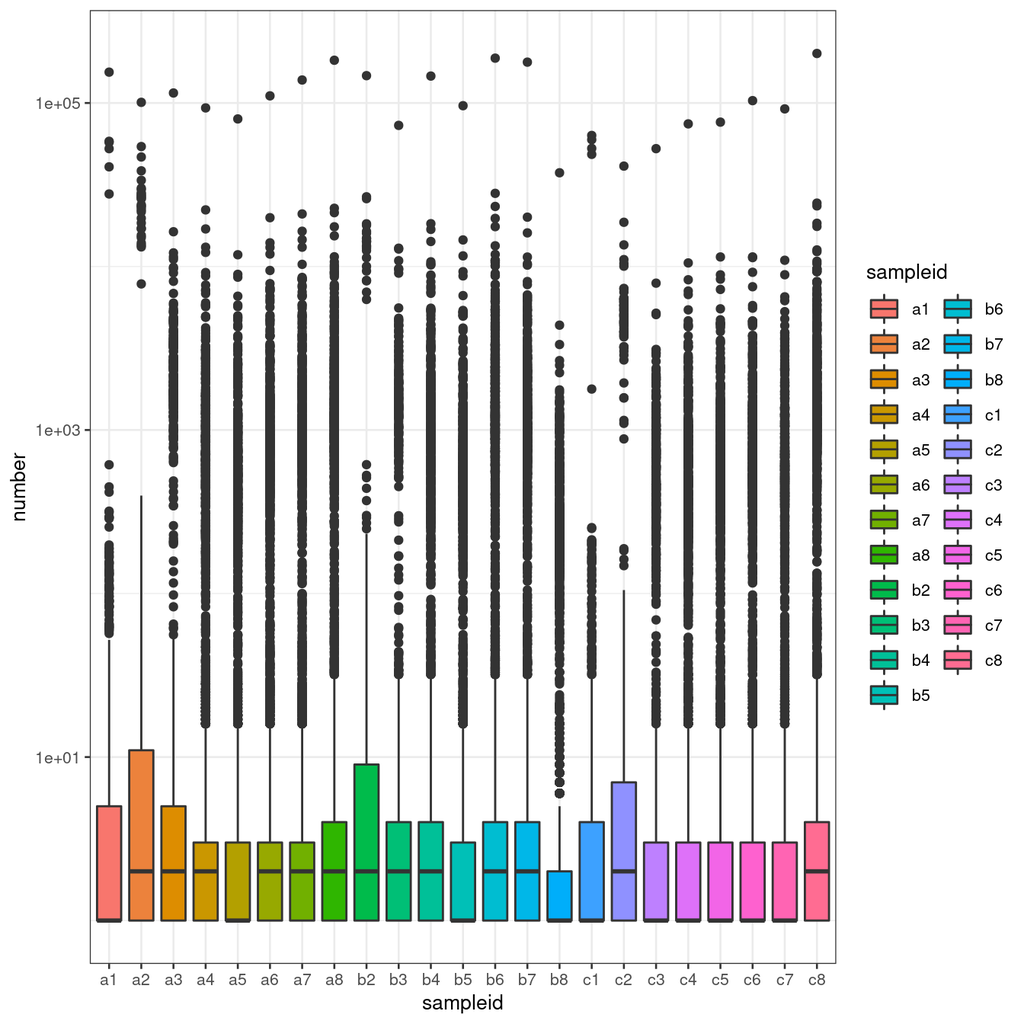

```r
meta <- qiime_tags[["modified_metadata"]]

## Number of reads / tag
plot_read_density(qiime_tags)
```

## 7.3 My method using the perl tag counts

```r
perl_tags <- read_tags(meta, index_column = "indextable")
summary(perl_tags)
```

```
##                   Length Class      Mode
## modified_metadata 20     data.frame list
## long_samples       5     data.frame list
## sample_counts     24     data.table list
```

```r
## read_idx returns a list with 3 elements:
##  the input metadata with some new columns.
##  the counts in a long format for easier plotting.
##  the counts in a wide format, which is easier to work with.
head(perl_tags[["modified_metadata"]])
```

```
##    sampleid replicate   batch        type    cfu dilution
## a1       a1         a b202012 calibration      4    1e-07
## a2       a2         a b202012 calibration     37    1e-06
## a3       a3         a b202012 calibration    450    1e-05
## a4       a4         a b202012 calibration   3850    1e-04
## a5       a5         a b202012 calibration  30000    1e-03
## a6       a6         a b202012 calibration 345000    1e-02
##                        rawfastq                            trimmedfastq
## a1 preprocessing/a1/r1.fastq.xz preprocessing/a1/r1-trimmed_ca.fastq.xz
## a2 preprocessing/a2/r1.fastq.xz preprocessing/a2/r1-trimmed_ca.fastq.xz
## a3 preprocessing/a3/r1.fastq.xz preprocessing/a3/r1-trimmed_ca.fastq.xz
## a4 preprocessing/a4/r1.fastq.xz preprocessing/a4/r1-trimmed_ca.fastq.xz
## a5 preprocessing/a5/r1.fastq.xz preprocessing/a5/r1-trimmed_ca.fastq.xz
## a6 preprocessing/a6/r1.fastq.xz preprocessing/a6/r1-trimmed_ca.fastq.xz
##                           indextable                       qiimeotus condition
## a1 preprocessing/a1/idx_count.txt.xz preprocessing/a1/a1_otus.txt.xz undefined
## a2 preprocessing/a2/idx_count.txt.xz preprocessing/a2/a2_otus.txt.xz undefined
## a3 preprocessing/a3/idx_count.txt.xz preprocessing/a3/a3_otus.txt.xz undefined
## a4 preprocessing/a4/idx_count.txt.xz preprocessing/a4/a4_otus.txt.xz undefined
## a5 preprocessing/a5/idx_count.txt.xz preprocessing/a5/a5_otus.txt.xz undefined
## a6 preprocessing/a6/idx_count.txt.xz preprocessing/a6/a6_otus.txt.xz undefined
##    qiime_reads qiime_observed qiime_max_reads_per_tag pre_reads post_reads
## a1      405682            952                  154397    346699     346144
## a2      789602           2276                  100920    788645     787643
## a3      619649           5134                  115116    594907     592146
## a4      664013           7772                   93305    644097     639403
## a5      481701           6899                   79884    468742     464175
## a6      723521           8744                  110553    703948     698526
##    observed passed_cutoff rejected_cutoff max_reads_per_tag
## a1      716           259             457            155537
## a2     1678           837             841            101708
## a3     3878          1716            2162            116012
## a4     5778          2093            3685             94056
## a5     5206          1579            3627             80581
## a6     6458          2216            4242            111445
```

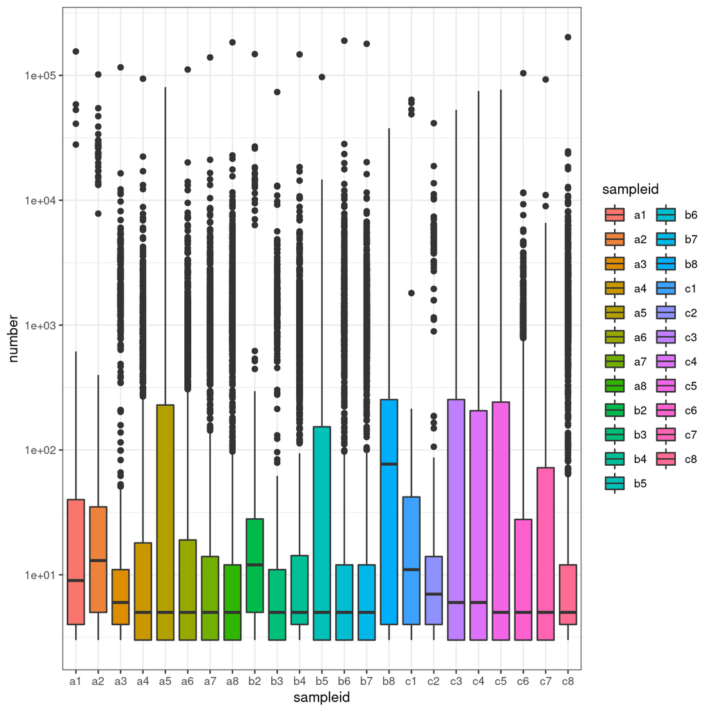

```r
## The new elements in the metadata include:
##  reads:  how many reads were used in this counting.
##  observed: how many tags were observed.
##  passed_cutoff: how many tags passed our simple cutoff for 'real'.
##  rejected_cutoff: passed + rejected = observed
##  max: What is the maximum number of reads for 1 tag.  Thus for a1, we see that one tag sucked up
##       almost half of all the reads.

## Given the above, we can trivially plot how many reads/tag there are for each sample:
plot_read_density(perl_tags)
```

## 7.4 The original qiime tally file

Note that the original method has a slightly different format.

```r
original_tag_file <- system.file("extdata/original_qiime_tally.csv", package = "stampr")
original_tags <- read.csv(original_tag_file)
head(original_tags)
```

```
##   X   A1.txt_seq A1.txt   A2.txt_seq A2.txt   A3.txt_seq A3.txt   A4.txt_seq
## 1 1 AAGAGTGACATC      1 GACAGATTGCTT     35 TTCTTTAACTAA      3 CCTCTAACGAAT
## 2 2 CTAGATATGGTT      5 CAAGGTATTCGT      2 CATAATCAACGA      2 GAACGATTATAA
## 3 3 GGATTGTCATTC      1 TATCCATTATCC      2 CCATGAGAATCT    920 TTCGATAGAAAA
## 4 4 TATTTAAAAACG      2 CTATTAAAGATT     15 ATTCGGCCAGGA      1 ATAGTCAACTAC
## 5 5 TAAAAGGCAATC      1 TTCGCTCTTTTT      4 TTAATCCGAGAA      1 ACGATCGAACAA
## 6 6  AGAAATAAGGG      2 CTTCGGTAACAT      1 TAGTTTAAGTAT     14 GGTATAGGTTCC
##   A4.txt   A5.txt_seq A5.txt   A6.txt_seq A6.txt   A7.txt_seq A7.txt
## 1      4 TTCCTTTTCTAA      1 AACATCTGTGTT      3 ACTACGGTTGAA     27
## 2      3 GCGGTACTGGAA      1 GAAACCGCTAGC      2 TTAACTTAAGTA      1
## 3      6 AAGATCCCTCAA      1 TGACTATAATAC      1  TTGCAAAGATT      1
## 4      1 TACAGATGGAAG      1 TATGGATACGAT      1 AGCGACGTAACT      1
## 5      2 AAAGCTTAGAAC      4 CGAACTCGAATA      1 AAGACTTTAAAT      1
## 6    171 GAGCGACGAATT   2118 TTACTCAAAAAA      1 GAAACCGCTAGC      6
##     A8.txt_seq A8.txt   B2.txt_seq B2.txt   B3.txt_seq B3.txt   B4.txt_seq
```

[output cut: 34 more lines]

# 8 Filter the tags

There are lots of ways one may choose to filter the tags to get the set of ‘real’ tags. Ideally, one would take the tags observed in the reference samples and remove anything not in it. Sadly, in our current data, there are far far fewer tags in the references than the calibration samples, so I have not implemented that. Conversely, one might choose to remove tags observed in < x samples. I haven’t implemented that yet either. I did, however, cpm() the matrix and remove anything less than 1x the number of samples (which is configurable).

```r
new_meta <- perl_tags[["modified_metadata"]]
current_tags <- perl_tags[["sample_counts"]]
filtered_tags <- filter_tags(perl_tags)
summary(filtered_tags)
```

```
##                   Length Class      Mode
## filtered          77579  -none-     numeric
## modified_metadata    21  data.frame list
```

```r
head(filtered_tags[["modified_metadata"]])
```

```
##    sampleid replicate   batch        type    cfu dilution
## a1       a1         a b202012 calibration      4    1e-07
## a2       a2         a b202012 calibration     37    1e-06
## a3       a3         a b202012 calibration    450    1e-05
## a4       a4         a b202012 calibration   3850    1e-04
## a5       a5         a b202012 calibration  30000    1e-03
## a6       a6         a b202012 calibration 345000    1e-02
##                        rawfastq                            trimmedfastq
## a1 preprocessing/a1/r1.fastq.xz preprocessing/a1/r1-trimmed_ca.fastq.xz
## a2 preprocessing/a2/r1.fastq.xz preprocessing/a2/r1-trimmed_ca.fastq.xz
## a3 preprocessing/a3/r1.fastq.xz preprocessing/a3/r1-trimmed_ca.fastq.xz
## a4 preprocessing/a4/r1.fastq.xz preprocessing/a4/r1-trimmed_ca.fastq.xz
## a5 preprocessing/a5/r1.fastq.xz preprocessing/a5/r1-trimmed_ca.fastq.xz
## a6 preprocessing/a6/r1.fastq.xz preprocessing/a6/r1-trimmed_ca.fastq.xz
##                           indextable                       qiimeotus condition
## a1 preprocessing/a1/idx_count.txt.xz preprocessing/a1/a1_otus.txt.xz undefined
## a2 preprocessing/a2/idx_count.txt.xz preprocessing/a2/a2_otus.txt.xz undefined
## a3 preprocessing/a3/idx_count.txt.xz preprocessing/a3/a3_otus.txt.xz undefined
## a4 preprocessing/a4/idx_count.txt.xz preprocessing/a4/a4_otus.txt.xz undefined
## a5 preprocessing/a5/idx_count.txt.xz preprocessing/a5/a5_otus.txt.xz undefined
## a6 preprocessing/a6/idx_count.txt.xz preprocessing/a6/a6_otus.txt.xz undefined
##    qiime_reads qiime_observed qiime_max_reads_per_tag pre_reads post_reads
## a1      405682            952                  154397    346699     346144
## a2      789602           2276                  100920    788645     787643
## a3      619649           5134                  115116    594907     592146
## a4      664013           7772                   93305    644097     639403
## a5      481701           6899                   79884    468742     464175
## a6      723521           8744                  110553    703948     698526
##    observed passed_cutoff rejected_cutoff max_reads_per_tag
## a1      716           259             457            155537
## a2     1678           837             841            101708
## a3     3878          1716            2162            116012
## a4     5778          2093            3685             94056
## a5     5206          1579            3627             80581
## a6     6458          2216            4242            111445
##    passed_aggressive_cpm
## a1                   231
## a2                   597
## a3                  1361
## a4                  1831
## a5                  1492
## a6                  1988
```

```r
## Thus the new column 'passed_aggressive_cpm'
```

# 9 Quantify the Nb values.

## 9.1 The original with slight changes

The following block contains the original code with slight modifications and produces the same Nb values as provided.

```r
inputdata <- "../../original/BigMatAll_STAMP_CAUTI_calcurve1_working.csv"
### read input sequence data file
## Data = as.matrix(read.csv(inputdata,row.names = 1))
Data <- read.csv(inputdata)
rownames(Data) <- make.names(Data[["X"]], unique = TRUE)
Data[["X"]] <- NULL

#BigMatAll = DataII[,2:ncol(DataII)]
BigMatAll <- Data

### USER ### define output filename
name <- "New_EstimateMatrix_CAUTI_Calcurve1"

### shows colnames and col # to make it easier to identify the reference samples
### and the data samples
cbind(1:ncol(BigMatAll), colnames(BigMatAll))

### should a calibration curve be used to normalize the data? TRUE/FALSE
usecalibrationcurve <- FALSE

### USER ### If calibration curve is used, give path to calibration data
### ("CalibrationLookup")
if (usecalibrationcurve) {
  load("/Users/kerbachta/Desktop/STAMP/calcurve3/CalibrationLookup.Rdata")
}

### USER ### define which columns of BigMatAll contain real read numbers and not
### meta-data like binaries, average count number or absolute presence in
### samples. Usually column 1 to 24 (1:24) contain real read numbers.
v.reads <- 1:23

### USER ### define which columns of BigMatAll contain reference samples
### (usually the inoculum)? Define at least two columns e.g. 1:2 or c(1,2) would
### mean column 1 and column 2 of BigMatAll contain reference samples.
## v.reference <- 21:23
v.reference <- c(8, 15, 23)

### USER ### define which columns of BigMatAll contain data samples (that should
### be the columns of BigMatAll that contain real read numbers minus the
### reference columns)
## v.bottlenecksamples <- 1:20
v.bottlenecksamples <- c(1:7, 9:14, 16:22)

### define threshold for inocula (e.g. sequence must be present at least once)
v.threshold <- which(rowSums(BigMatAll[, v.reference], na.rm = TRUE) > 0)

### choose real reads
ThresholdMatrix <- BigMatAll[v.threshold, v.reads]

## Why was this not done first?
### NA= 0 (not present)
ThresholdMatrix[is.na(ThresholdMatrix) == TRUE] <- 0

### Create matrix with references only
ReferenceMatrix <- ThresholdMatrix[, v.reference]
head(ReferenceMatrix)

### Define FrequenzMatrix
fReferenceMatrix <- matrix(nrow = nrow(ReferenceMatrix),
                           ncol = ncol(ReferenceMatrix),
                           dimnames = list(rownames(ReferenceMatrix),
                                         colnames(ReferenceMatrix)))

### Fill FrequenzMatrix with frequencies
for(x in 1:ncol(fReferenceMatrix)) {
    fReferenceMatrix[, x] <- ReferenceMatrix[, x] / sum(ReferenceMatrix[, x])
}

### Average frequencies
fTotalInoculum <- rowMeans(fReferenceMatrix, na.rm = TRUE)

### make matrix that connects bottleneckestimate to columnname
EstimateMatrix <- matrix(nrow = 5, ncol = length(v.bottlenecksamples))
colnames(EstimateMatrix) <- colnames(BigMatAll[, v.bottlenecksamples])
rownames(EstimateMatrix) <- c("Nb","lower CI","Nb'_median","upper CI","# sequences")

### define expected counts and frequencies
expectedCounts <- rowMeans(ReferenceMatrix, na.rm = TRUE)
expvec <- fTotalInoculum[expectedCounts > 0]
inoculumSize <- sum(ReferenceMatrix, na.rm = TRUE)

### loop for estimating Ne for each sample
for (i in 1:length(v.bottlenecksamples)) {
  bnvec <- ThresholdMatrix[, v.bottlenecksamples[i]]
  bnvec <- bnvec[expectedCounts > 0]
  sampleSize <- sum(bnvec)
  binomialNenner <- expvec * (1 - expvec)
  measured <- bnvec / sum(bnvec)
  var <- (measured - expvec) ^ 2
  binomial <- as.numeric(var) / as.numeric(binomialNenner)
  BSize <- 1 / (mean(binomial) - 1 / sampleSize - 1 / inoculumSize)
  EstimateMatrix[1, i] <- BSize
  Log10BSize <- round(log10(BSize), 2)
  EstimateMatrix[5, i] <- sampleSize
### this part of the code compares to the lookupmatrix
  if (usecalibrationcurve) {
    if (Log10BSize < max(as.numeric(rownames(LookUpMatrix)))) {
      if (usecalibrationcurve) {
        EstimateMatrix[2:4, i] <- 10 ^ LookUpMatrix[as.character(Log10BSize), ]
      }
    }
  }
}

head(EstimateMatrix)
tmp <- t(EstimateMatrix)
meta[["Nb_original"]] <- 0
for (l in 1:nrow(tmp)) {
  row <- tmp[l, ]
  name <- rownames(tmp)[l]
  name <- tolower(gsub(x = name, pattern = "\\.txt", replacement = ""))
  meta[name, "Nb_original"] <- row[["Nb"]]
}
```

## 9.2 My version from the index counts

```r
my_nb <- calculate_nb(perl_tags, metadata_column = "MyNb")
```

## 9.3 Calculate Nb after top-n tag filtering.

```r
topn_filtered <- filter_topn_tags(my_nb, topn = 600)
topn600_nb <- calculate_nb(topn_filtered, metadata_column = "Nb600")
top500_filtered <- filter_topn_tags(topn600_nb, topn = 500)
topn500_nb <- calculate_nb(top500_filtered, metadata_column = "Nb500",
                           write = "modified_metadata-20210105.xlsx")
```

# 10 Create Calibration curve

```r
cali_curve <- plot_calibration(topn500_nb)
cali_curve$lm
```

```
##
## Call:
## lm(formula = plot_formula, data = cali)
##
## Coefficients:
## (Intercept)            x
##       2.541        0.636
```

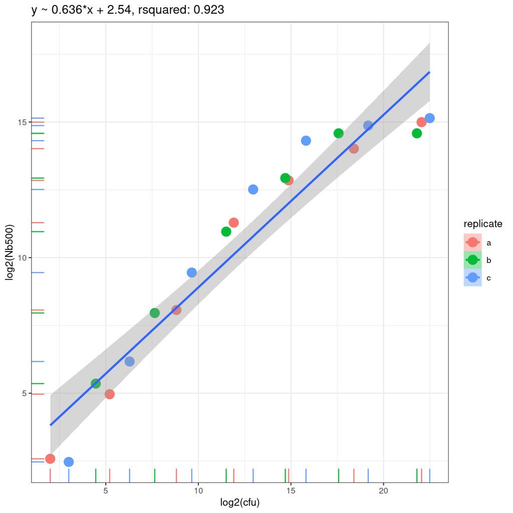

```r
hpgltools::pp(file = "conservative_calibration_curve.png", image = cali_curve$plot)
```